# Social Diversity Regression Analyses

Brandon Kramer

### Objective

In this report, we use logistic regression to predict the likelihood of "social diversity" being used in biomedical abstracts. Our dataset includes ~2.5 million abstracts from 250 top-ranked biomedical journals taken from the PubMed/MEDLINE database. For a summary of our methodology, see our [supplementary website](https://growthofdiversity.netlify.app/methods/). To understand the models below, you need to understand that our response/outcome variable is "social diversity," which is any mention of diversity (1/0) that co-occurs with one of the other 392 total terms from the other 11 diversity cateogories in H1. Our predictor variables will include year of publication, the categories from H1, H2, and H3 as well as control variables like whether human or animal terms were used in the abstracts. In the latter models, we also included journal information such as whether the abstracts derived from prominent biomedical franchises such as *Annual Reviews*, *Nature*, *Lancet*, and *Trends*. We also classified biomedical journals into 13 categories, including biotech/bioengineering, biological sciences, brain sciences, cancer research, cardiovascular sciences, general multidisciplinary science journals (Nature, Science, etc.), genomic/genetic sciences, immunology/infectious disease sciences, internal medicine, pharmaceutical sciences, public health, surgery, and other (i.e. combination of urology, gynecology, pediatrics, and nursing).

NOTE: I've looked at the data to ensure that there is no missing data and looked the correlations to the outcome. Despite the outcome, in part, being defined by some of the predictors, those variables are not strongly correlated.

### Logistic Regression Models

The overall objective is to develop a model that has the lowest residual deviance score. After each model, I will run an ANOVA to test whether the most recent model is an improvement over the previous versions we ran.

#### H1-H3 Categories

Our first model evaluates the effect of the H1 categories (diversity) on our outcome.

```r
model1 <- glm(soc_diversity ~ year + cultural + disability + equity + lifecourse + migration +
               minority + race_ethnicity + sex_gender + sexuality + social_class,
               data = train, family = "binomial")
summary(model1)
```

```
##
## Call:
## glm(formula = soc_diversity ~ year + cultural + disability +
##     equity + lifecourse + migration + minority + race_ethnicity +
##     sex_gender + sexuality + social_class, family = "binomial",
##     data = train)
##
## Deviance Residuals:
##     Min       1Q   Median       3Q      Max
## -3.8272  -0.1320  -0.1161  -0.0943   3.4961
##
## Coefficients:
##                  Estimate Std. Error z value Pr(>|z|)
## (Intercept)    -1.086e+02  2.717e+00 -39.967   <2e-16 ***
## year            5.145e-02  1.350e-03  38.117   <2e-16 ***
## cultural        5.717e-01  1.692e-02  33.791   <2e-16 ***
## disability      1.290e-01  1.443e-02   8.934   <2e-16 ***
## equity          4.896e-02  1.778e-02   2.753   0.0059 **
## lifecourse      9.784e-02  2.532e-03  38.649   <2e-16 ***
## migration       1.903e-01  1.611e-02  11.810   <2e-16 ***
## minority        2.632e-01  2.264e-02  11.624   <2e-16 ***
## race_ethnicity  2.873e-01  7.049e-03  40.756   <2e-16 ***
## sex_gender      7.091e-02  3.230e-03  21.953   <2e-16 ***
## sexuality       1.073e-01  8.646e-03  12.405   <2e-16 ***
## social_class    2.035e-01  1.192e-02  17.079   <2e-16 ***
## ---
## Signif. codes:  0 '***' 0.001 '**' 0.01 '*' 0.05 '.' 0.1 ' ' 1
##
## (Dispersion parameter for binomial family taken to be 1)
##
##     Null deviance: 138359  on 1507013  degrees of freedom
## Residual deviance: 129935  on 1507002  degrees of freedom
## AIC: 129959
##
## Number of Fisher Scoring iterations: 8
```

This model shows that each of the H1 categories has a significant and positive effect on social diversity being mentioned. Our second model looks at the H2 categories (OMB/Census categories).

```r
model2 <- glm(soc_diversity ~ year + asian + black + ethnic + hispanic +
               native_american + pacific_islander + racial + white,
               data = train, family = "binomial")
summary(model2)
```

```
##
## Call:
## glm(formula = soc_diversity ~ year + asian + black + ethnic +
##     hispanic + native_american + pacific_islander + racial +
##     white, family = "binomial", data = train)
##
## Deviance Residuals:
##    Min      1Q  Median      3Q     Max
## -3.495  -0.143  -0.125  -0.098   3.530
##
## Coefficients:
##                    Estimate Std. Error z value Pr(>|z|)
## (Intercept)      -1.139e+02  2.701e+00 -42.171  < 2e-16 ***
## year              5.419e-02  1.342e-03  40.387  < 2e-16 ***
## asian             1.415e-01  2.130e-02   6.642 3.10e-11 ***
## black             2.126e-01  1.744e-02  12.185  < 2e-16 ***
## ethnic            5.158e-01  1.424e-02  36.222  < 2e-16 ***
## hispanic          1.225e-01  1.845e-02   6.641 3.11e-11 ***
## native_american   2.580e-01  3.692e-02   6.990 2.74e-12 ***
## pacific_islander  2.454e-02  7.215e-02   0.340    0.734
## racial            1.347e-01  1.637e-02   8.232  < 2e-16 ***
## white            -1.394e-01  2.512e-02  -5.551 2.84e-08 ***
## ---
## Signif. codes:  0 '***' 0.001 '**' 0.01 '*' 0.05 '.' 0.1 ' ' 1
##
## (Dispersion parameter for binomial family taken to be 1)
##
##     Null deviance: 138359  on 1507013  degrees of freedom
## Residual deviance: 133399  on 1507004  degrees of freedom
## AIC: 133419
##
## Number of Fisher Scoring iterations: 8
```

```r
anova(model1, model2, test = "Chisq")
```

```
## Analysis of Deviance Table
##
## Model 1: soc_diversity ~ year + cultural + disability + equity + lifecourse +
##     migration + minority + race_ethnicity + sex_gender + sexuality +
##     social_class
## Model 2: soc_diversity ~ year + asian + black + ethnic + hispanic + native_american +
##     pacific_islander + racial + white
##   Resid. Df Resid. Dev Df Deviance  Pr(>Chi)
## 1   1507002     129935
## 2   1507004     133399 -2  -3463.7 < 2.2e-16 ***
## ---
## Signif. codes:  0 '***' 0.001 '**' 0.01 '*' 0.05 '.' 0.1 ' ' 1
```

```r
model3 <- glm(soc_diversity ~ year + continental + directional + national +
                 omb_uscensus + race_ethnicity + subcontinental + subnational,
               data = train, family = "binomial")
summary(model3)
```

```
##
## Call:
## glm(formula = soc_diversity ~ year + continental + directional +
##     national + omb_uscensus + race_ethnicity + subcontinental +
##     subnational, family = "binomial", data = train)
##
## Deviance Residuals:
##     Min       1Q   Median       3Q      Max
## -4.5305  -0.1364  -0.1199  -0.0950   3.4854
##
## Coefficients:
##                  Estimate Std. Error z value Pr(>|z|)
## (Intercept)    -1.092e+02  2.712e+00 -40.252  < 2e-16 ***
## year            5.181e-02  1.348e-03  38.443  < 2e-16 ***
## continental     1.672e-01  8.169e-03  20.471  < 2e-16 ***
## directional     1.313e-01  1.108e-02  11.854  < 2e-16 ***
## national        1.113e-01  5.429e-03  20.493  < 2e-16 ***
## omb_uscensus    8.559e-04  7.242e-03   0.118    0.906
## race_ethnicity  3.207e-01  8.135e-03  39.425  < 2e-16 ***
## subcontinental  8.397e-02  1.372e-02   6.121 9.27e-10 ***
## subnational     1.225e-01  9.107e-03  13.445  < 2e-16 ***
## ---
## Signif. codes:  0 '***' 0.001 '**' 0.01 '*' 0.05 '.' 0.1 ' ' 1
##
## (Dispersion parameter for binomial family taken to be 1)
##
##     Null deviance: 138359  on 1507013  degrees of freedom
## Residual deviance: 131337  on 1507005  degrees of freedom
## AIC: 131355
##
## Number of Fisher Scoring iterations: 8
```

```r
anova(model1, model3, test = "Chisq")
```

```
## Analysis of Deviance Table
##
## Model 1: soc_diversity ~ year + cultural + disability + equity + lifecourse +
##     migration + minority + race_ethnicity + sex_gender + sexuality +
##     social_class
## Model 2: soc_diversity ~ year + continental + directional + national +
##     omb_uscensus + race_ethnicity + subcontinental + subnational
##   Resid. Df Resid. Dev Df Deviance  Pr(>Chi)
## 1   1507002     129935
## 2   1507005     131337 -3  -1401.4 < 2.2e-16 ***
## ---
## Signif. codes:  0 '***' 0.001 '**' 0.01 '*' 0.05 '.' 0.1 ' ' 1
```

```r
anova(model2, model3, test = "Chisq")
```

```
## Analysis of Deviance Table
##
## Model 1: soc_diversity ~ year + asian + black + ethnic + hispanic + native_american +
##     pacific_islander + racial + white
## Model 2: soc_diversity ~ year + continental + directional + national +
##     omb_uscensus + race_ethnicity + subcontinental + subnational
##   Resid. Df Resid. Dev Df Deviance Pr(>Chi)
## 1   1507004     133399
## 2   1507005     131337 -1   2062.3
```

This model shows that after bringing in the H3 categories, the OMB/Census categories are no longer significant in predicting the social diversity outcome. Instead, all of the other cateogories are significant and positive predictors. The ANOVAs also show that while model 3 does do better than model 2, model 1 is still the best overall model fit. Let's add all of those categories together (removing the ones with overlap such as racial and race/ethnicity).

```r
model7 <- glm(soc_diversity ~ year + human_study + animal_study + cultural + disability + equity + lifecourse +
                migration + minority + sex_gender + sexuality + social_class +
                asian + black + ethnic + hispanic + native_american + pacific_islander + racial + white +
                continental + directional + national + subcontinental + subnational,
              data = train, family = "binomial")
summary(model7)
```

```
##
## Call:
## glm(formula = soc_diversity ~ year + human_study + animal_study +
##     cultural + disability + equity + lifecourse + migration +
##     minority + sex_gender + sexuality + social_class + asian +
##     black + ethnic + hispanic + native_american + pacific_islander +
##     racial + white + continental + directional + national + subcontinental +
##     subnational, family = "binomial", data = train)
##
## Deviance Residuals:
##     Min       1Q   Median       3Q      Max
## -3.9094  -0.1261  -0.1102  -0.0898   3.5464
##
## Coefficients:
##                    Estimate Std. Error z value Pr(>|z|)
## (Intercept)      -1.081e+02  2.753e+00 -39.276  < 2e-16 ***
## year              5.113e-02  1.368e-03  37.379  < 2e-16 ***
## human_study       3.740e-01  2.181e-02  17.146  < 2e-16 ***
## animal_study      1.689e-01  3.381e-02   4.997 5.81e-07 ***
## cultural          5.057e-01  1.683e-02  30.040  < 2e-16 ***
## disability        1.109e-01  1.489e-02   7.448 9.45e-14 ***
## equity            5.273e-02  1.766e-02   2.985  0.00283 **
## lifecourse        9.381e-02  2.621e-03  35.789  < 2e-16 ***
## migration         1.161e-01  1.766e-02   6.576 4.84e-11 ***
## minority          2.410e-01  2.250e-02  10.712  < 2e-16 ***
## sex_gender        4.222e-02  3.657e-03  11.543  < 2e-16 ***
## sexuality         1.103e-01  8.602e-03  12.817  < 2e-16 ***
## social_class      1.653e-01  1.264e-02  13.081  < 2e-16 ***
## asian            -2.254e-01  2.476e-02  -9.106  < 2e-16 ***
## black             1.203e-01  1.667e-02   7.217 5.30e-13 ***
## ethnic            3.595e-01  1.447e-02  24.841  < 2e-16 ***
## hispanic          7.900e-02  1.721e-02   4.591 4.42e-06 ***
## native_american   8.187e-02  3.952e-02   2.072  0.03830 *
## pacific_islander  5.515e-02  6.930e-02   0.796  0.42611
## racial            1.576e-01  1.574e-02  10.014  < 2e-16 ***
## white            -1.516e-01  2.326e-02  -6.518 7.11e-11 ***
## continental       1.888e-01  8.444e-03  22.356  < 2e-16 ***
## directional       1.297e-01  1.132e-02  11.456  < 2e-16 ***
## national          5.166e-02  5.995e-03   8.618  < 2e-16 ***
## subcontinental    1.155e-01  1.387e-02   8.330  < 2e-16 ***
## subnational       8.435e-02  9.792e-03   8.614  < 2e-16 ***
## ---
## Signif. codes:  0 '***' 0.001 '**' 0.01 '*' 0.05 '.' 0.1 ' ' 1
##
## (Dispersion parameter for binomial family taken to be 1)
##
##     Null deviance: 138359  on 1507013  degrees of freedom
## Residual deviance: 127553  on 1506988  degrees of freedom
## AIC: 127605
##
## Number of Fisher Scoring iterations: 8
```

```r
anova(model1, model7, test = "Chisq")
```

```
## Analysis of Deviance Table
##
## Model 1: soc_diversity ~ year + cultural + disability + equity + lifecourse +
##     migration + minority + race_ethnicity + sex_gender + sexuality +
##     social_class
## Model 2: soc_diversity ~ year + human_study + animal_study + cultural +
##     disability + equity + lifecourse + migration + minority +
##     sex_gender + sexuality + social_class + asian + black + ethnic +
##     hispanic + native_american + pacific_islander + racial +
##     white + continental + directional + national + subcontinental +
##     subnational
##   Resid. Df Resid. Dev Df Deviance  Pr(>Chi)
## 1   1507002     129935
## 2   1506988     127553 14     2382 < 2.2e-16 ***
## ---
## Signif. codes:  0 '***' 0.001 '**' 0.01 '*' 0.05 '.' 0.1 ' ' 1
```

```r
anova(model3, model7, test = "Chisq")
```

```
## Analysis of Deviance Table
##
## Model 1: soc_diversity ~ year + continental + directional + national +
##     omb_uscensus + race_ethnicity + subcontinental + subnational
## Model 2: soc_diversity ~ year + human_study + animal_study + cultural +
##     disability + equity + lifecourse + migration + minority +
##     sex_gender + sexuality + social_class + asian + black + ethnic +
##     hispanic + native_american + pacific_islander + racial +
##     white + continental + directional + national + subcontinental +
##     subnational
##   Resid. Df Resid. Dev Df Deviance  Pr(>Chi)
## 1   1507005     131337
## 2   1506988     127553 17   3783.4 < 2.2e-16 ***
## ---
## Signif. codes:  0 '***' 0.001 '**' 0.01 '*' 0.05 '.' 0.1 ' ' 1
```

Overall, this model confirms that the all of the H1 and H3 categories have a positive and significant impact on the use of social diversity in biomedical abstracts. In contrast, we see that only certain H2 categories have a significant positive effect, which helps to explain why the OMB/Census category was a non-siginificant predictor in the last model. Here, we see that terms like Black, Hispanic, Native American, racial and ethnic have positive effects while Asian and White have negative effects. While it makes sense why social diversity would be used less in conversations about White people, I suspect that diversity is not a discourse that would be used widely in biomedical studies conducted by Chinese scholars, which may be used terms within our Asian category to refer to Chinese populations more generally outside of population testing more specifically. This model also includes the human and animal indicator variables and the only thing that is notable here is that the animal studies have a positive effect, suggesting that we could spend more time working to build up our animal exclusion clause to remove false positives. Lastly, our model diagnostics show clearly that this is the best model we have so far.

#### Journal Information

Now, we can add in the four main publication franchises (*Annual Reviews*, *Nature*, *Lancet*, and *Trends*).

```r
model8 <- glm(soc_diversity ~ year + human_study + animal_study + cultural + disability + equity + lifecourse +
                migration + minority + sex_gender + sexuality + social_class +
                asian + black + ethnic + hispanic + native_american + pacific_islander + racial + white +
                continental + directional + national + subcontinental + subnational +
                nature + annual_reviews + lancet + trends_in,
              data = train, family = "binomial")
summary(model8)
```

```
##
## Call:
## glm(formula = soc_diversity ~ year + human_study + animal_study +
##     cultural + disability + equity + lifecourse + migration +
##     minority + sex_gender + sexuality + social_class + asian +
##     black + ethnic + hispanic + native_american + pacific_islander +
##     racial + white + continental + directional + national + subcontinental +
##     subnational + nature + annual_reviews + lancet + trends_in,
##     family = "binomial", data = train)
##
## Deviance Residuals:
##     Min       1Q   Median       3Q      Max
## -3.9296  -0.1280  -0.1109  -0.0887   3.5923
##
## Coefficients:
##                    Estimate Std. Error z value Pr(>|z|)
## (Intercept)      -1.084e+02  2.764e+00 -39.222  < 2e-16 ***
## year              5.126e-02  1.373e-03  37.322  < 2e-16 ***
## human_study       3.803e-01  2.182e-02  17.429  < 2e-16 ***
## animal_study      1.626e-01  3.382e-02   4.808 1.52e-06 ***
## cultural          5.023e-01  1.682e-02  29.870  < 2e-16 ***
## disability        1.124e-01  1.488e-02   7.554 4.21e-14 ***
## equity            5.339e-02  1.763e-02   3.028  0.00246 **
## lifecourse        9.596e-02  2.631e-03  36.478  < 2e-16 ***
## migration         1.138e-01  1.773e-02   6.419 1.37e-10 ***
## minority          2.430e-01  2.251e-02  10.799  < 2e-16 ***
## sex_gender        4.349e-02  3.654e-03  11.901  < 2e-16 ***
## sexuality         1.101e-01  8.601e-03  12.803  < 2e-16 ***
## social_class      1.714e-01  1.274e-02  13.452  < 2e-16 ***
## asian            -2.275e-01  2.481e-02  -9.170  < 2e-16 ***
## black             1.223e-01  1.668e-02   7.331 2.28e-13 ***
## ethnic            3.606e-01  1.447e-02  24.923  < 2e-16 ***
## hispanic          7.858e-02  1.723e-02   4.561 5.10e-06 ***
## native_american   7.751e-02  3.974e-02   1.950  0.05112 .
## pacific_islander  5.626e-02  6.930e-02   0.812  0.41688
## racial            1.561e-01  1.578e-02   9.895  < 2e-16 ***
## white            -1.533e-01  2.328e-02  -6.586 4.52e-11 ***
## continental       1.913e-01  8.452e-03  22.632  < 2e-16 ***
## directional       1.309e-01  1.135e-02  11.537  < 2e-16 ***
## national          5.609e-02  6.007e-03   9.338  < 2e-16 ***
## subcontinental    1.141e-01  1.390e-02   8.208 2.25e-16 ***
## subnational       8.504e-02  9.797e-03   8.681  < 2e-16 ***
## nature            1.997e-01  4.432e-02   4.507 6.58e-06 ***
## annual_reviews    9.773e-01  1.046e-01   9.344  < 2e-16 ***
## lancet           -7.547e-01  1.335e-01  -5.654 1.56e-08 ***
## trends_in         5.208e-01  9.614e-02   5.417 6.07e-08 ***
## ---
## Signif. codes:  0 '***' 0.001 '**' 0.01 '*' 0.05 '.' 0.1 ' ' 1
##
## (Dispersion parameter for binomial family taken to be 1)
##
##     Null deviance: 138359  on 1507013  degrees of freedom
## Residual deviance: 127406  on 1506984  degrees of freedom
## AIC: 127466
##
## Number of Fisher Scoring iterations: 8
```

```r
anova(model7, model8, test = "Chisq")
```

```
## Analysis of Deviance Table
##
## Model 1: soc_diversity ~ year + human_study + animal_study + cultural +
##     disability + equity + lifecourse + migration + minority +
##     sex_gender + sexuality + social_class + asian + black + ethnic +
##     hispanic + native_american + pacific_islander + racial +
##     white + continental + directional + national + subcontinental +
##     subnational
## Model 2: soc_diversity ~ year + human_study + animal_study + cultural +
##     disability + equity + lifecourse + migration + minority +
##     sex_gender + sexuality + social_class + asian + black + ethnic +
##     hispanic + native_american + pacific_islander + racial +
##     white + continental + directional + national + subcontinental +
##     subnational + nature + annual_reviews + lancet + trends_in
##   Resid. Df Resid. Dev Df Deviance  Pr(>Chi)
## 1   1506988     127553
## 2   1506984     127406  4    147.4 < 2.2e-16 ***
## ---
## Signif. codes:  0 '***' 0.001 '**' 0.01 '*' 0.05 '.' 0.1 ' ' 1
```

This model shows little difference in the H1-H3 categories, which is a good indication those effects are robust. For those top jounals, we see that *Annual Reviews*, *Nature*, and *Trends* have positive impacts while *Lancet* has a negative impact. Next, we will add in all of the categories (using Other as our reference cateogory).

```r
model10 <- glm(soc_diversity ~ year + human_study + animal_study + cultural + disability + equity + lifecourse +
                migration + minority + sex_gender + sexuality + social_class +
                asian + black + ethnic + hispanic + native_american + pacific_islander + racial + white +
                continental + directional + national + subcontinental + subnational +
                nature + annual_reviews + lancet + trends_in +
                bio_tech + bio_sciences + brain_sciences + cancer_research + cardio_sciences + general_sciences +
                genomic_sciences + immuno_infect + internal_medicine + pharma_sciences + public_health + surgery,
              data = train, family = "binomial")
summary(model10) # AIC: 208081
```

```
##
## Call:
## glm(formula = soc_diversity ~ year + human_study + animal_study +
##     cultural + disability + equity + lifecourse + migration +
##     minority + sex_gender + sexuality + social_class + asian +
##     black + ethnic + hispanic + native_american + pacific_islander +
##     racial + white + continental + directional + national + subcontinental +
##     subnational + nature + annual_reviews + lancet + trends_in +
##     bio_tech + bio_sciences + brain_sciences + cancer_research +
##     cardio_sciences + general_sciences + genomic_sciences + immuno_infect +
##     internal_medicine + pharma_sciences + public_health + surgery,
##     family = "binomial", data = train)
##
## Deviance Residuals:
##     Min       1Q   Median       3Q      Max
## -3.9377  -0.1331  -0.1056  -0.0783   3.7302
##
## Coefficients:
##                     Estimate Std. Error z value Pr(>|z|)
## (Intercept)       -96.475402   2.833103 -34.053  < 2e-16 ***
## year                0.045282   0.001410  32.119  < 2e-16 ***
## human_study         0.362405   0.021823  16.606  < 2e-16 ***
## animal_study        0.105066   0.033989   3.091  0.00199 **
## cultural            0.487324   0.016915  28.811  < 2e-16 ***
## disability          0.101586   0.015119   6.719 1.83e-11 ***
## equity              0.047690   0.017607   2.709  0.00676 **
## lifecourse          0.097575   0.002664  36.623  < 2e-16 ***
## migration           0.108779   0.017659   6.160 7.27e-10 ***
## minority            0.256186   0.022781  11.246  < 2e-16 ***
## sex_gender          0.047138   0.003613  13.046  < 2e-16 ***
## sexuality           0.100042   0.008764  11.415  < 2e-16 ***
## social_class        0.156452   0.012897  12.131  < 2e-16 ***
## asian              -0.207862   0.025136  -8.269  < 2e-16 ***
## black               0.126512   0.016636   7.604 2.86e-14 ***
## ethnic              0.355978   0.014501  24.548  < 2e-16 ***
## hispanic            0.083247   0.017271   4.820 1.44e-06 ***
## native_american     0.064932   0.040812   1.591  0.11161
## pacific_islander    0.091009   0.067871   1.341  0.17995
## racial              0.166654   0.015572  10.702  < 2e-16 ***
## white              -0.126818   0.023178  -5.471 4.47e-08 ***
```

[output cut: 16 more lines]

```
## immuno_infect       0.251210   0.052621   4.774 1.81e-06 ***
## internal_medicine  -0.145525   0.056087  -2.595  0.00947 **
## pharma_sciences    -0.079813   0.054253  -1.471  0.14126
## public_health       0.341415   0.052884   6.456 1.08e-10 ***
## surgery            -0.695414   0.085559  -8.128 4.37e-16 ***
## ---
## Signif. codes:  0 '***' 0.001 '**' 0.01 '*' 0.05 '.' 0.1 ' ' 1
##
## (Dispersion parameter for binomial family taken to be 1)
##
##     Null deviance: 138359  on 1507013  degrees of freedom
## Residual deviance: 125594  on 1506972  degrees of freedom
## AIC: 125678
##
## Number of Fisher Scoring iterations: 8
```

```r
anova(model8, model10, test = "Chisq")
```

```
## Analysis of Deviance Table
##
## Model 1: soc_diversity ~ year + human_study + animal_study + cultural +
##     disability + equity + lifecourse + migration + minority +
##     sex_gender + sexuality + social_class + asian + black + ethnic +
##     hispanic + native_american + pacific_islander + racial +
##     white + continental + directional + national + subcontinental +
##     subnational + nature + annual_reviews + lancet + trends_in
## Model 2: soc_diversity ~ year + human_study + animal_study + cultural +
##     disability + equity + lifecourse + migration + minority +
##     sex_gender + sexuality + social_class + asian + black + ethnic +
##     hispanic + native_american + pacific_islander + racial +
##     white + continental + directional + national + subcontinental +
##     subnational + nature + annual_reviews + lancet + trends_in +
##     bio_tech + bio_sciences + brain_sciences + cancer_research +
##     cardio_sciences + general_sciences + genomic_sciences + immuno_infect +
##     internal_medicine + pharma_sciences + public_health + surgery
##   Resid. Df Resid. Dev Df Deviance  Pr(>Chi)
## 1   1506984     127406
## 2   1506972     125594 12   1812.1 < 2.2e-16 ***
## ---
## Signif. codes:  0 '***' 0.001 '**' 0.01 '*' 0.05 '.' 0.1 ' ' 1
```

### Model Diagnostics

One way to validate this and check the performance of these regression models is looking at the pseudo (McFadden's) R-squared statistics. We see that we improve over the models, but there McFadden's is still pretty low overall.

```r
list(model1 = pscl::pR2(model1)["McFadden"],
     model2 = pscl::pR2(model2)["McFadden"],
     model3 = pscl::pR2(model3)["McFadden"],
     model7 = pscl::pR2(model7)["McFadden"],
     model8 = pscl::pR2(model8)["McFadden"],
     model10 = pscl::pR2(model10)["McFadden"])
```

```
## fitting null model for pseudo-r2
## fitting null model for pseudo-r2
## fitting null model for pseudo-r2
## fitting null model for pseudo-r2
## fitting null model for pseudo-r2
## fitting null model for pseudo-r2
```

```
## $model1
##   McFadden
## 0.06088466
##
## $model2
##   McFadden
## 0.03585073
##
## $model3
##   McFadden
## 0.05075615
##
## $model7
##   McFadden
## 0.07810095
##
## $model8
##   McFadden
## 0.07916631
##
## $model10
##   McFadden
## 0.09226359
```

We also want to see how good the model is at predicting the outcome on the rest of our testing data.

```r
test_predicted_m1 <- predict(model1, newdata = test, type = "response")
test_predicted_m2 <- predict(model2, newdata = test, type = "response")
test_predicted_m3 <- predict(model3, newdata = test, type = "response")
test_predicted_m7 <- predict(model7, newdata = test, type = "response")
test_predicted_m8 <- predict(model8, newdata = test, type = "response")
test_predicted_m10 <- predict(model10, newdata = test, type = "response")

list(
  model1 = table(test$soc_diversity, test_predicted_m1 > 0.5) %>% prop.table() %>% round(3),
  model2 = table(test$soc_diversity, test_predicted_m2 > 0.5) %>% prop.table() %>% round(3),
  model3 = table(test$soc_diversity, test_predicted_m3 > 0.5) %>% prop.table() %>% round(3),
  model7 = table(test$soc_diversity, test_predicted_m7 > 0.5) %>% prop.table() %>% round(3),
  model8 = table(test$soc_diversity, test_predicted_m8 > 0.5) %>% prop.table() %>% round(3),
  model10 = table(test$soc_diversity, test_predicted_m10 > 0.5) %>% prop.table() %>% round(3)
)
```

```
## $model1
##
##     FALSE  TRUE
##   0 0.992 0.000
##   1 0.008 0.000
##
## $model2
##
##     FALSE  TRUE
##   0 0.992 0.000
##   1 0.008 0.000
##
## $model3
##
##     FALSE  TRUE
##   0 0.992 0.000
##   1 0.008 0.000
##
## $model7
##
##     FALSE  TRUE
##   0 0.992 0.000
##   1 0.008 0.000
##
## $model8
##
##     FALSE  TRUE
##   0 0.992 0.000
##   1 0.008 0.000
##
## $model10
##
##     FALSE  TRUE
##   0 0.992 0.000
##   1 0.008 0.000
```

While the chance of Type-II errors is really low (0.8%), the model's capacity to actually predict social diversity is really poor (99% are false negatives). Additional analyses show we have a low error rate and that this is the case across all of our models. Given our McFadden's statistics, this is not all that surprising.

```r
table(test$soc_diversity, test_predicted_m10 > 0.5)
```

```
##
##      FALSE   TRUE
##   0 995296    216
##   1   7693     47
```

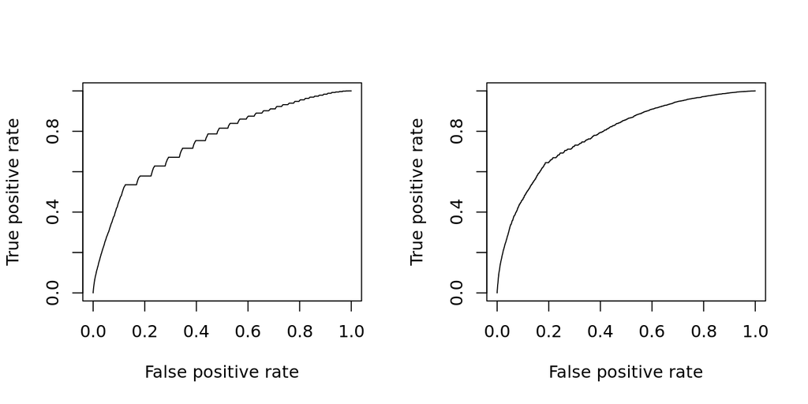

```r
par(mfrow=c(1, 2))

prediction(test_predicted_m1, test$soc_diversity) %>%
  performance(measure = "tpr", x.measure = "fpr") %>%
  plot()

prediction(test_predicted_m10, test$soc_diversity) %>%
  performance(measure = "tpr", x.measure = "fpr") %>%
  plot()
```

```r
prediction(test_predicted_m1, test$soc_diversity) %>%
  performance(measure = "auc") %>%
  .@y.values
```

```
## [[1]]
## [1] 0.7527047
```

```r
prediction(test_predicted_m10, test$soc_diversity) %>%
  performance(measure = "auc") %>%
  .@y.values
```

```
## [[1]]
## [1] 0.7896003
```

When we look at the ROC, we see that the model is fine (it improved from our original model), but is still under the 0.80 that is recommended to use. Taken together, this means that we really should spend some more time engineering some additional features to predict the outcomes. That is, we could do some additional text mining of the abstracts to pull out other predictors such as clinical research indicators, mention of specific biological entities, etc. We could also do some additional refinement of our exclusion clause to improve the accuracy of our original heuristic. That said, this all seems like a step we could take in a future project.

### References

[UC Business Analytics R Programming Guide for Logistic Regression](https://uc-r.github.io/logistic_regression)